# BHao_HW4

## 7.8.1.a. Plot the series and discuss the main features of the data.

The data represent daily unit sales for paperback and hardcover books at the same store over 30 days. Optically, it appears that sales trend upward, but there are no obvious patterns in day-to-day sales.

```r
library(fma)
```

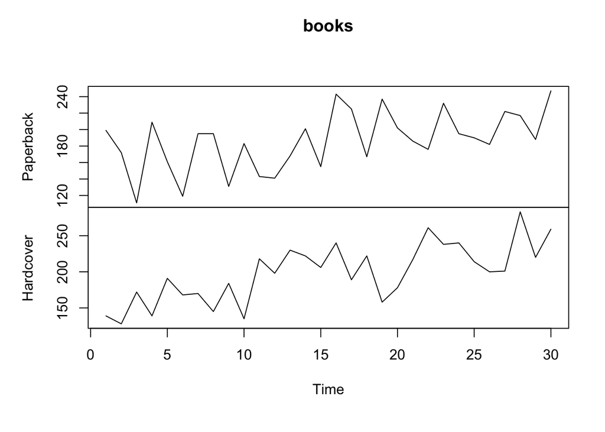

```r
plot(books)
```

## 7.8.1.b. Use simple exponential smoothing with the ses function (setting initial=“simple”) and explore different values of αα for the paperback series. Record the within-sample SSE for the one-step forecasts. Plot SSE against αα and find which value of αα works best. What is the effect of αα on the forecasts?

In this case, the smaller alpha value 0.2 performed much better in terms of SSE than did the larger alpha value 0.6.

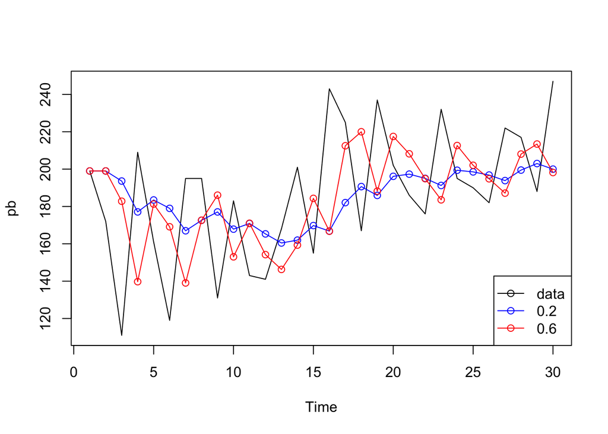

```r
pb = books[, 'Paperback']

fit1 = ses(pb, alpha = 0.2, initial = 'simple')
fit2 = ses(pb, alpha = 0.6, initial = 'simple')
plot(pb)
lines(fitted(fit1), col='blue', type='o')
lines(fitted(fit2), col='red' , type='o')
legend('bottomright', lty=1, col=c(1,'blue','red'),
       c('data', expression(a = 0.2), expression(a = 0.6)),
         pch=1)
```

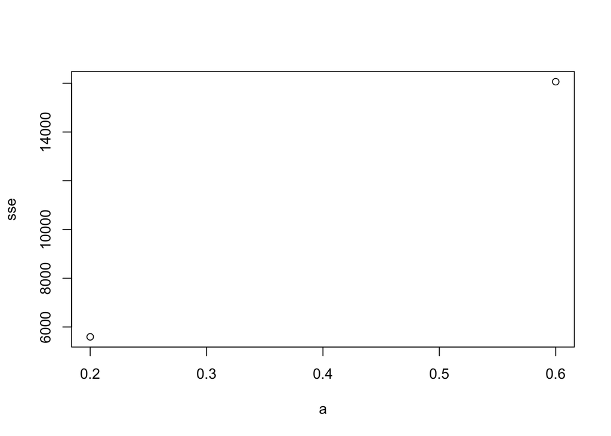

```r
sse1 = sum((fitted(fit1) - mean(pb))^2)
sse2 = sum((fitted(fit2) - mean(pb))^2)

plot(data.frame(a = c(0.2, 0.6), sse = c(sse1, sse2)))
```

## 7.8.1.c. Now let ses select the optimal value of αα. Use this value to generate forecasts for the next four days. Compare your results with 2.

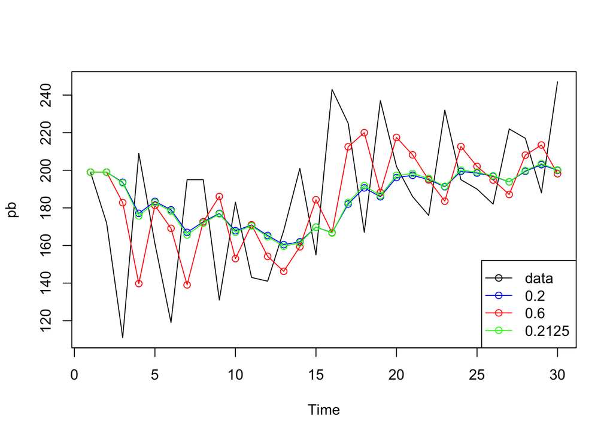

```r
fit3 = ses(pb, initial = 'simple')

plot(pb)
lines(fitted(fit1), col='blue' , type='o')
lines(fitted(fit2), col='red'  , type='o')
lines(fitted(fit3), col='green', type='o')
legend('bottomright', lty=1, col=c(1,'blue','red','green'),
       c('data', expression(a = 0.2), expression(a = 0.6), expression(a = 0.2125)),
         pch=1)
```

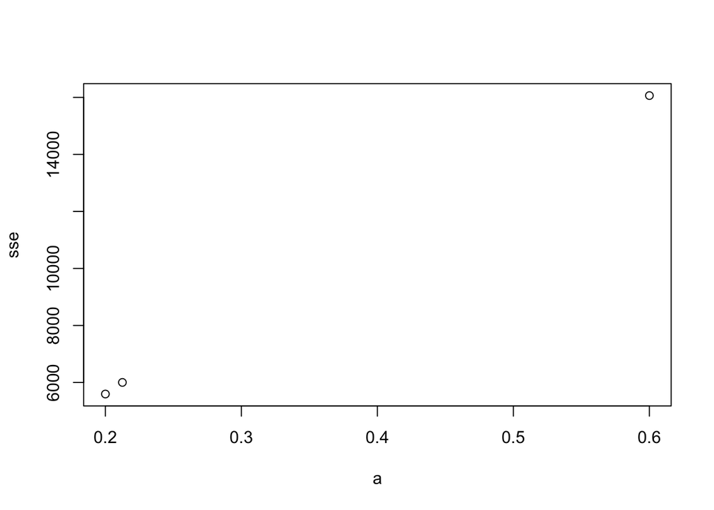

```r
sse3 = sum((fitted(fit3) - mean(pb))^2)

plot(data.frame(a = c(0.2, 0.6, 0.2125), sse = c(sse1, sse2, sse3)))
```

## 7.8.1.d. Repeat but with initial=“optimal”. How much difference does an optimal initial level make?

Interestingly, allowing ses to select the optimal initial value, the resulting SSE was higher than than above.

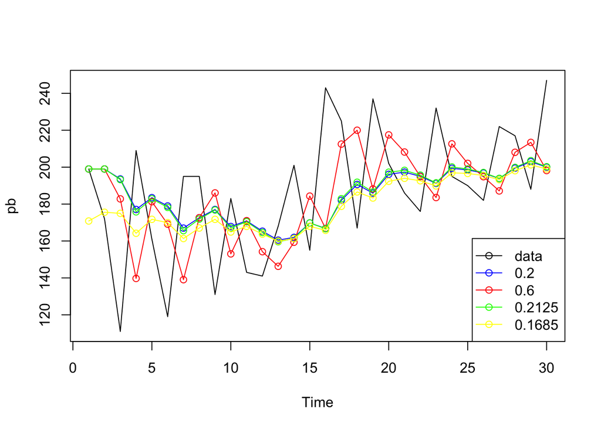

```r
fit4 = ses(pb, initial = 'optimal')

plot(pb)
lines(fitted(fit1), col='blue'  , type='o')
lines(fitted(fit2), col='red'   , type='o')
lines(fitted(fit3), col='green' , type='o')
lines(fitted(fit4), col='yellow', type='o')
legend('bottomright', lty=1, col=c(1,'blue','red','green','yellow'),
       c('data', expression(a = 0.2), expression(a = 0.6), expression(a = 0.2125), expression(a = 0.1685)),
         pch=1)
```

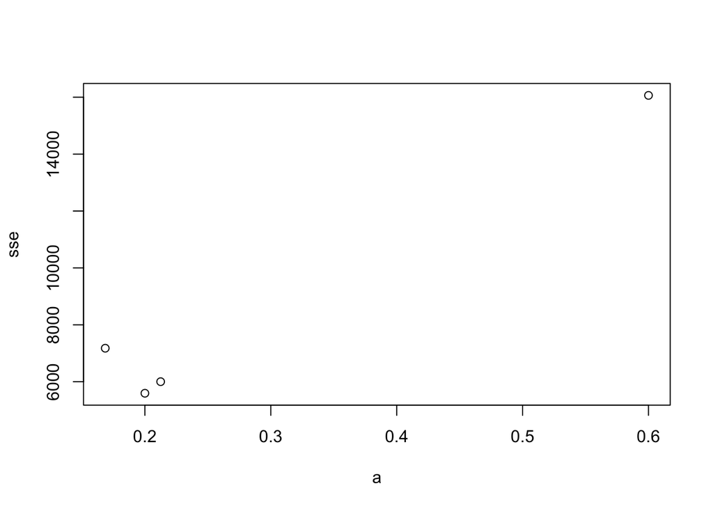

```r
sse4 = sum((fitted(fit4) - mean(pb))^2)

plot(data.frame(a = c(0.2, 0.6, 0.2125, 0.1685), sse = c(sse1, sse2, sse3, sse4)))
```

## 7.8.1.e Repeat steps (b)–(d) with the hardcover series.

In the case of hardcovers, allowing ses to select the optimal initial and alpha values resulted in the lowest SSE by far.

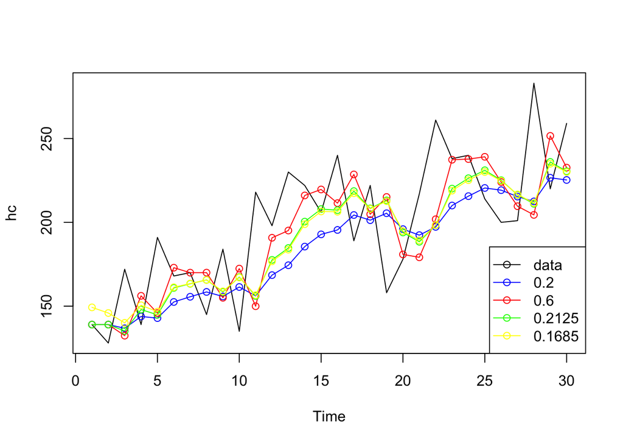

```r
hc = books[, 'Hardcover']

fit1 = ses(hc, alpha = 0.2, initial = 'simple')
fit2 = ses(hc, alpha = 0.6, initial = 'simple')
fit3 = ses(hc, initial = 'simple')
fit4 = ses(hc, initial = 'optimal')

plot(hc)
lines(fitted(fit1), col='blue'  , type='o')
lines(fitted(fit2), col='red'   , type='o')
lines(fitted(fit3), col='green' , type='o')
lines(fitted(fit4), col='yellow', type='o')
legend('bottomright', lty=1, col=c(1,'blue','red','green','yellow'),
       c('data', expression(a = 0.2), expression(a = 0.6), expression(a = 0.2125), expression(a = 0.1685)),
         pch=1)
```

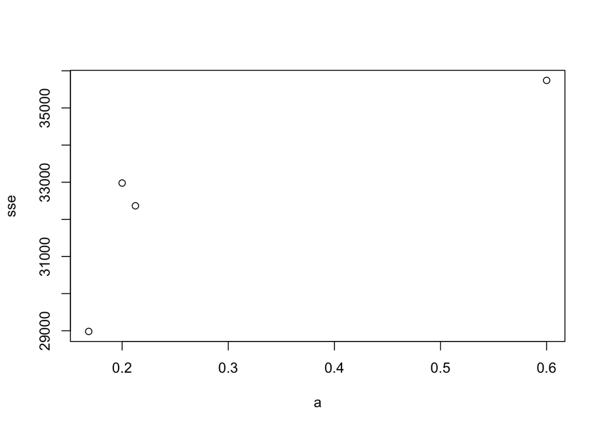

```r
sse1 = sum((fitted(fit1) - mean(hc))^2)
sse2 = sum((fitted(fit2) - mean(hc))^2)
sse3 = sum((fitted(fit3) - mean(hc))^2)
sse4 = sum((fitted(fit4) - mean(hc))^2)

plot(data.frame(a = c(0.2, 0.6, 0.2125, 0.1685), sse = c(sse1, sse2, sse3, sse4)))
```

## 7.8.3.a. Plot the data and describe the main features of the series.

There is a clear upward trend in the data over time as well as clear seasonality.

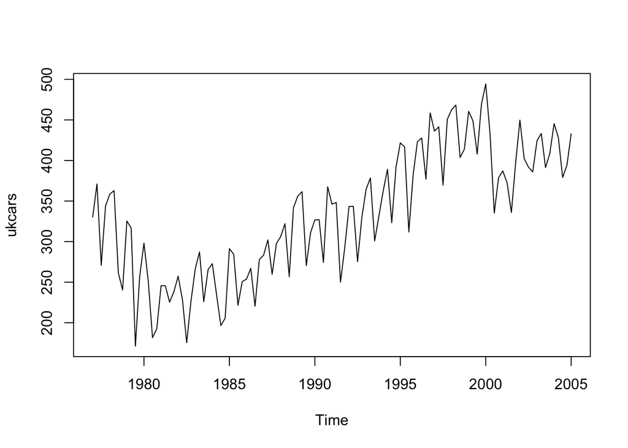

```r
library(expsmooth)
plot(ukcars)
```

## 7.8.3.b. Decompose the series using STL and obtain the seasonally adjusted data.

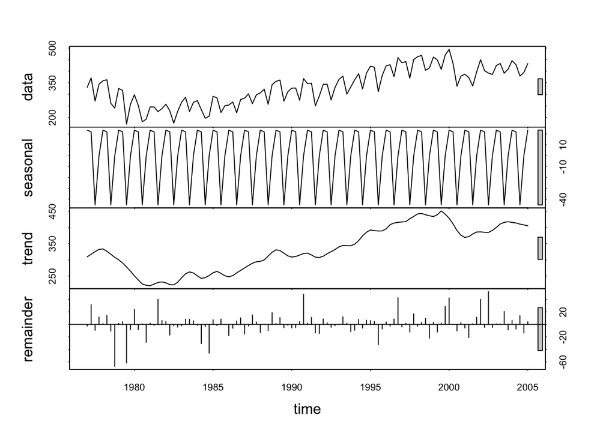

```r
fit_stl = stl(ukcars, s.window = 'periodic', robust = TRUE)
plot(fit_stl)
```

## 7.8.3.c. Forecast the next two years of the series using an additive damped trend method applied to the seasonally adjusted data. Then reseasonalize the forecasts. Record the parameters of the method and report the RMSE of the one-step forecasts from your method.

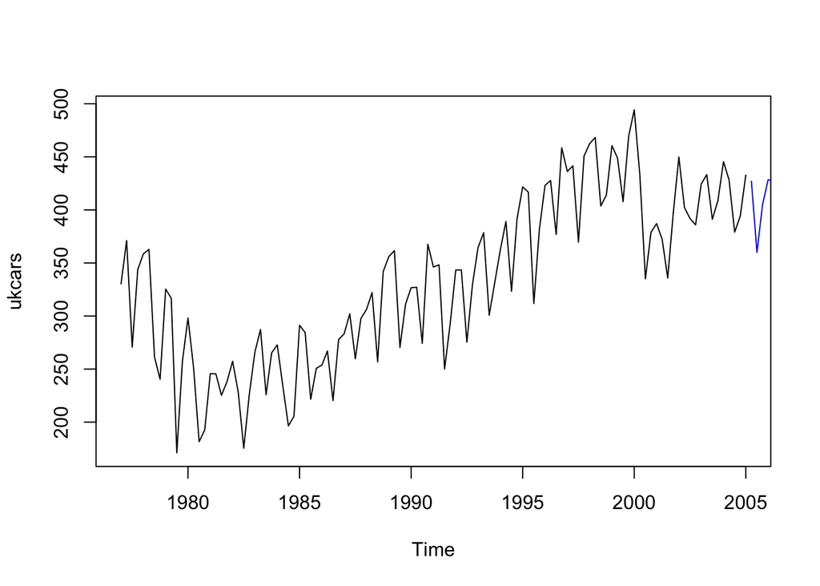

```r
ukcars_seasAdj = fit_stl$time.series[, 'trend']
reSeas = as.numeric(tail(fit_stl$time.series[, 'seasonal'], 8))  # use prev 8 periods to reseasonalize forecast

fit_damped = ses(ukcars_seasAdj, h = 8, damped = TRUE)
fit_damped_reSeas = fit_damped$mean + reSeas  # combine with forecasted mean

plot(ukcars)
lines(fit_damped_reSeas, col='blue')
```

```r
# output model parameters
summary(fit_damped)
```

```
##
## Forecast method: Simple exponential smoothing
##
## Model Information:
## Simple exponential smoothing
##
## Call:
##  ses(y = ukcars_seasAdj, h = 8, damped = TRUE)
##
##   Smoothing parameters:
##     alpha = 0.9999
##
##   Initial states:
##     l = 309.5501
##
##   sigma:  7.5104
##
##       AIC      AICc       BIC
##  995.8765  996.0967 1004.0587
##
## Error measures:
##                     ME     RMSE      MAE       MPE     MAPE      MASE
## Training set 0.8455707 7.510414 6.240617 0.2092296 1.972227 0.3181851
##                  ACF1
## Training set 0.766302
##
## Forecasts:
##         Point Forecast    Lo 80    Hi 80    Lo 95    Hi 95
## 2005 Q2         405.09 395.4650 414.7150 390.3698 419.8101
## 2005 Q3         405.09 391.4789 418.7011 384.2736 425.9064
## 2005 Q4         405.09 388.4201 421.7598 379.5957 430.5843
## 2006 Q1         405.09 385.8415 424.3385 375.6519 434.5281
## 2006 Q2         405.09 383.5696 426.6104 372.1774 438.0026
## 2006 Q3         405.09 381.5157 428.6643 369.0362 441.1438
## 2006 Q4         405.09 379.6269 430.5531 366.1475 444.0325
## 2007 Q1         405.09 377.8688 432.3112 363.4588 446.7212
```

## 7.8.3.d. Forecast the next two years of the series using Holt’s linear method applied to the seasonally adjusted data. Then reseasonalize the forecasts. Record the parameters of the method and report the RMSE of of the one-step forecasts from your method.

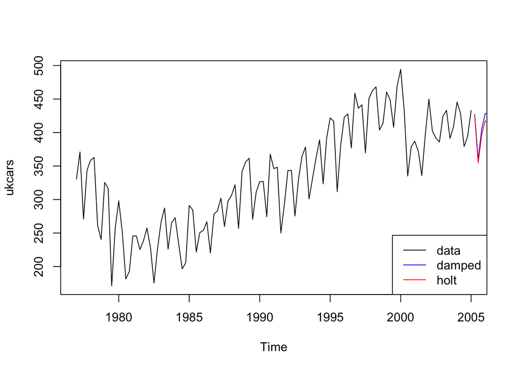

```r
fit_holt = holt(ukcars_seasAdj, h = 8)
fit_holt_reSeas = fit_holt$mean + reSeas

plot(ukcars)
lines(fit_damped_reSeas, col='blue')
lines(fit_holt_reSeas  , col='red')
legend('bottomright', lty=1, col=c(1,'blue','red'),
       c('data', 'damped', 'holt'))
```

```r
# output model parameters
summary(fit_holt)
```

```
##
## Forecast method: Holt's method
##
## Model Information:
## Holt's method
##
## Call:
##  holt(y = ukcars_seasAdj, h = 8)
##
##   Smoothing parameters:
##     alpha = 0.9999
##     beta  = 0.9999
##
##   Initial states:
##     l = 299.8252
##     b = 14.2267
##
##   sigma:  5.0564
##
##      AIC     AICc      BIC
## 910.4623 911.0231 924.0993
##
## Error measures:
##                      ME     RMSE      MAE           MPE     MAPE      MASE
## Training set -0.1504732 5.056389 3.901235 -0.0008004432 1.218107 0.1989089
##                   ACF1
## Training set 0.3659724
##
## Forecasts:
##         Point Forecast    Lo 80    Hi 80    Lo 95    Hi 95
## 2005 Q2       402.3147 395.8347 408.7947 392.4044 412.2251
## 2005 Q3       399.5397 385.0511 414.0283 377.3813 421.6981
## 2005 Q4       396.7647 372.5210 421.0084 359.6872 433.8422
## 2006 Q1       393.9897 358.5007 429.4787 339.7140 448.2654
## 2006 Q2       391.2147 343.1625 439.2669 317.7251 464.7042
## 2006 Q3       388.4397 326.6306 450.2487 293.9108 482.9685
## 2006 Q4       385.6646 308.9999 462.3293 268.4161 502.9132
## 2007 Q1       382.8896 290.3460 475.4332 241.3564 524.4228
```

## 7.8.3.e. Now use ets() to choose a seasonal model for the data.

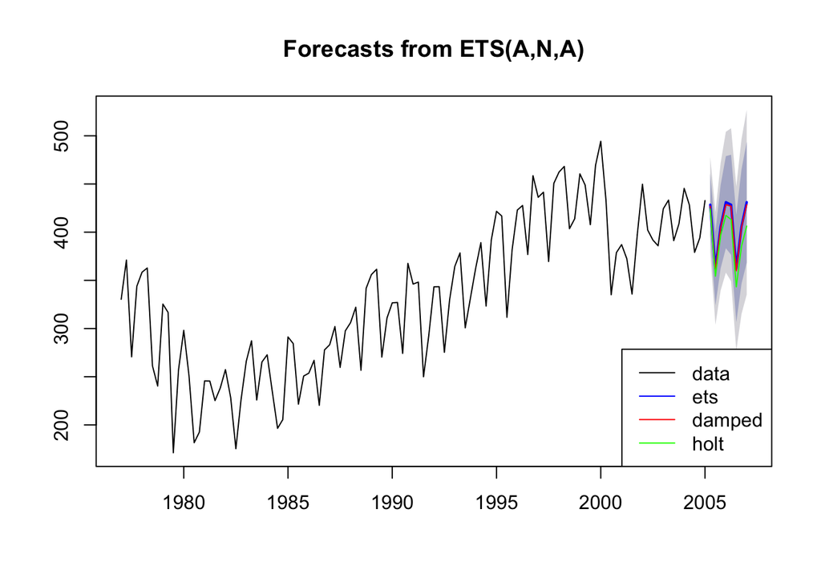

```r
fit_ets = ets(ukcars)

plot(forecast(fit_ets, h = 8))
lines(fit_damped_reSeas, col='red')
lines(fit_holt_reSeas  , col='green')
legend('bottomright', lty=1, col=c(1,'blue','red','green'),
       c('data', 'ets', 'damped', 'holt'))
```

```r
# output model parameters
summary(fit_ets)
```

```
## ETS(A,N,A)
##
## Call:
##  ets(y = ukcars)
##
##   Smoothing parameters:
##     alpha = 0.6267
##     gamma = 1e-04
##
##   Initial states:
##     l = 313.0916
##     s=-1.1271 -44.606 21.5553 24.1778
##
##   sigma:  25.2579
##
##      AIC     AICc      BIC
## 1277.980 1279.047 1297.072
##
## Training set error measures:
##                    ME     RMSE      MAE        MPE     MAPE      MASE
## Training set 1.324962 25.25792 20.12508 -0.1634983 6.609629 0.6558666
##                    ACF1
## Training set 0.01909295
```

## 7.8.3.f. Compare the RMSE of the fitted model with the RMSE of the model you obtained using an STL decomposition with Holt’s method. Which gives the better in-sample fits?

The linear Holt method produced the lowest in-sample RMSE.

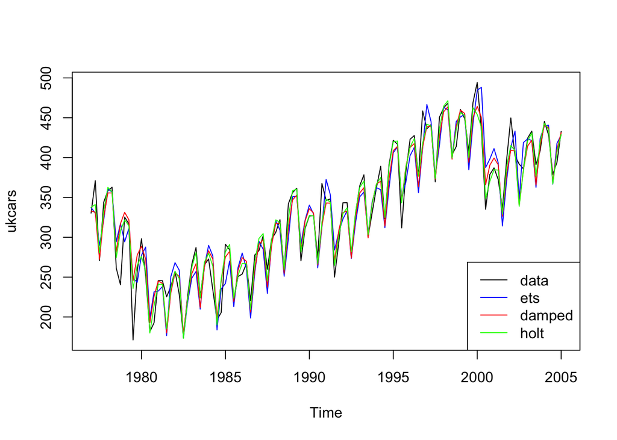

```r
plot(ukcars)
lines(fitted(fit_ets), col='blue')
# although the below two comparisons are not exactly fair since they are using the actual seasonality estimates
lines(fitted(fit_damped) + fit_stl$time.series[, 'seasonal'], col='red')
lines(fitted(fit_holt) + fit_stl$time.series[, 'seasonal'], col='green')
legend('bottomright', lty=1, col=c(1,'blue','red','green'),
       c('data', 'ets', 'damped', 'holt'))
```

```r
data.frame(c('ets', 'damped', 'holt'),
           c(sqrt(fit_ets$mse), sqrt(fit_damped$model$mse), sqrt(fit_holt$model$mse)))
```

```
##   c..ets....damped....holt..
## 1                        ets
## 2                     damped
## 3                       holt
##   c.sqrt.fit_ets.mse...sqrt.fit_damped.model.mse...sqrt.fit_holt.model.mse..
## 1                                                                  25.257919
## 2                                                                   7.510414
## 3                                                                   5.056389
```

## 7.8.3.g. Compare the forecasts from the two approaches? Which seems most reasonable?